# Night warming treatments

Debora

4/23/2025

Historical temperatures recorded every 15 minutes from 1998 to 2020 were downloaded from the Data Archives webpage (http://weather.uwaterloo.ca/data.html) maintained by the University of Waterloo Weather Station (43°28’27.5”N 80°33’24.4”W), Ontario, Canada. Date and temperature formatting was standardized and data cleaning was performed to remove any incorrect entries caused by technical errors (such as unrealistic temperature entries of 100 °C) using R Studio software. This dataset was then subset to the period of June 1-10, which represents late Spring in temperate regions. This period has been chosen because it occurs in the growing season, where any effects to performance can be more readily observed. In addition, other night warming experiments were conducted using this same timeframe (e.g., Zhao et al., 2014; Barton & Schmitz, 2017; Higashi, Barton, & Oliver, 2020). To simulate night warming treatments, the clean file saved on GitHub was then downloaded to R.

```r
refjune <- read.csv("https://raw.githubusercontent.com/Cuddington-Lab/thermal-experiments/main/historical_temps_analyses/historical_temperatures_uwaterloo_june_1_10.csv", header=TRUE, stringsAsFactors = TRUE)

head(refjune)
```

```
##       Date    Time Temperature      DateTime month year hour day
## 1 6/1/1998 0:00:00       6.823 6/1/1998 0:00     6 1998    0   1
## 2 6/1/1998 0:15:00       6.547 6/1/1998 0:15     6 1998    0   1
## 3 6/1/1998 0:30:00       6.213 6/1/1998 0:30     6 1998    0   1
## 4 6/1/1998 0:45:00       5.994 6/1/1998 0:45     6 1998    0   1
## 5 6/1/1998 1:00:00       5.803 6/1/1998 1:00     6 1998    1   1
## 6 6/1/1998 1:15:00       5.737 6/1/1998 1:15     6 1998    1   1
```

Next, very cold and very hot years, such as 1998 and 2020, have been excluded from the dataset so that it contains mostly years representative of average current conditions.

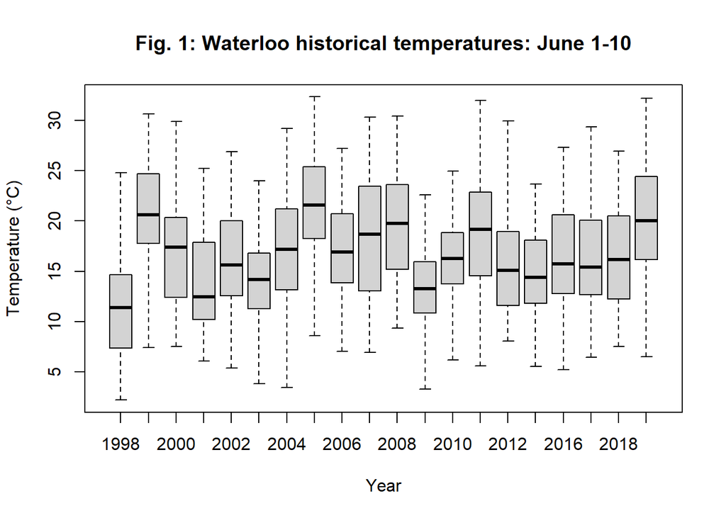

```r
boxplot(Temperature~year, data=refjune, main="Fig. 1: Waterloo historical temperatures: June 1-10",
        outline=FALSE, xlab="Year", ylab="Temperature (°C)",
        names = levels(as.factor(refjune$year)))
```

```r
refjune<-subset(refjune, !(year==1998 | year==1999 | year== 2005
                           | year== 2009| year== 2020))
```

Mean hourly temperatures were then obtained across years. This composed a reference 24-hour temperature sequence which is named “control”, as it is the basis for the control treatment.

```r
refjune <- aggregate(list(control=refjune$Temperature),
                     by = list(time=refjune$hour), mean)
head(refjune)
```

```
##   time  control
## 1    0 13.67270
## 2    1 13.26294
## 3    2 12.96297
## 4    3 12.67259
## 5    4 12.44668
## 6    5 12.37298
```

Minimum and maximum temperatures were extracted from this reference temperature sequence (note: “time2” column represents fictitious hours from 1-15, as it would be hard to fit a linear model using actual hours which are not in a crescent order, ie. start at 3pm and end at 5am).

```r
reftemps <- data.frame(cbind(time2 = c(15,1),
                             subset(refjune,
                                    control == max(refjune$control)
                                    | control == min(refjune$control))))
```

```r
reftemps$night_warm <- ifelse(reftemps$control==min(reftemps$control),
                      reftemps$control+5, reftemps$control)

reftemps$ambient_plus <- reftemps$control+2.5

head(reftemps)
```

```
##    time2 time  control night_warm ambient_plus
## 6     15    5 12.37298   17.37298     14.87298
## 16     1   15 20.52177   20.52177     23.02177
```

Next, linear models were created based on maximum and minimum temperatures, along with the respective hours in which they occurred.

```r
lm_func <- function(y) lm(y ~ time, data = reftemps)

lapply(reftemps[,3:5], lm_func)
```

```
## $control
##
## Call:
## lm(formula = y ~ time, data = reftemps)
##
## Coefficients:
## (Intercept)         time
##      8.2986       0.8149
##
##
## $night_warm
##
## Call:
## lm(formula = y ~ time, data = reftemps)
##
## Coefficients:
## (Intercept)         time
##     15.7986       0.3149
##
##
## $ambient_plus
##
## Call:
## lm(formula = y ~ time, data = reftemps)
##
## Coefficients:
## (Intercept)         time
##     10.7986       0.8149
```

```r
fit <- lm(cbind(control, night_warm, ambient_plus) ~ time, data = reftemps)

thermalseq <- data.frame(time=c(5:15))
thermalseq <- data.frame(cbind(time=thermalseq$time,(predict(fit,thermalseq))))

head(thermalseq)
```

```
##   time  control night_warm ambient_plus
## 1    5 12.37298   17.37298     14.87298
## 2    6 13.18786   17.68786     15.68786
## 3    7 14.00274   18.00274     16.50274
## 4    8 14.81762   18.31762     17.31762
## 5    9 15.63250   18.63250     18.13250
## 6   10 16.44738   18.94738     18.94738
```

```r
lm_func2 <- function(y) lm(y ~ time2, data = reftemps)

lapply(reftemps[,3:5], lm_func2)
```

```
## $control
##
## Call:
## lm(formula = y ~ time2, data = reftemps)
##
## Coefficients:
## (Intercept)        time2
##     21.1038      -0.5821
##
##
## $night_warm
##
## Call:
## lm(formula = y ~ time2, data = reftemps)
##
## Coefficients:
## (Intercept)        time2
##     20.7467      -0.2249
##
##
## $ambient_plus
##
## Call:
## lm(formula = y ~ time2, data = reftemps)
##
## Coefficients:
## (Intercept)        time2
##     23.6038      -0.5821
```

```r
fit2 <- lm(cbind(control, night_warm, ambient_plus) ~ time2, data = reftemps)

thermalseq2 <- data.frame(time2=c(1:15))
thermalseq2 <- data.frame(cbind(time2=thermalseq2$time2,
                                (predict(fit2,thermalseq2))))

head(thermalseq2)
```

```
##   time2  control night_warm ambient_plus
## 1     1 20.52177   20.52177     23.02177
## 2     2 19.93972   20.29686     22.43972
## 3     3 19.35766   20.07194     21.85766
## 4     4 18.77560   19.84703     21.27560
## 5     5 18.19355   19.62212     20.69355
## 6     6 17.61149   19.39720     20.11149
```

Fictitious hours were replaced by actual hours and predictions from the 2 linear models were bound together.

```r
thermalseq2$time2 <- c(15:23,0:5)
colnames(thermalseq2)[1] <- "time"

thermalseq3 <- rbind(thermalseq,thermalseq2)
thermalseq3 <- thermalseq3[order(thermalseq3$time),]
thermalseq3 <- thermalseq3[!duplicated(thermalseq3$time), ]
rownames(thermalseq3) <- NULL
```

Creating a random treatment for the night warming spring experiment

```r
set.seed(1234)
# Generate an initial sequence of random values
random <- rnorm(24, mean = mean(thermalseq3$night_warm), sd = sd(thermalseq3$night_warm))

# Clip values to stay within the range of night warming
random <- pmax(pmin(random, max(thermalseq3$night_warm)), min(thermalseq3$night_warm))

# Adjust mean and sd directly
current_mean <- mean(random)
current_sd <- sd(random)

# Scale and shift
random <- (random - current_mean) / current_sd * sd(thermalseq3$night_warm) + mean(thermalseq3$night_warm)

# Clip again to ensure it stays within bounds
random <- pmax(pmin(random, max(thermalseq3$night_warm)), min(thermalseq3$night_warm))

thermalseq3$random <- random

rbind(
  night_warm = c(mean = mean(thermalseq3$night_warm), sd = sd(thermalseq3$night_warm), min = min(thermalseq3$night_warm), max = max(thermalseq3$night_warm)),
  random = c(mean = mean(thermalseq3$random), sd = sd(thermalseq3$random), min = min(thermalseq3$random), max = max(thermalseq3$random))
)
```

```
##                mean        sd      min      max
## night_warm 18.94738 0.9351364 17.37298 20.52177
## random     18.92525 0.8618465 17.37298 20.52177
```

```r
head(thermalseq3)
```

```
##   time  control night_warm ambient_plus   random
## 1    0 15.28326   18.49755     17.78326 17.79396
## 2    1 14.70121   18.27264     17.20121 19.53902
## 3    2 14.11915   18.04772     16.61915 20.48769
## 4    3 13.53709   17.82281     16.03709 17.37298
## 5    4 12.95504   17.59790     15.45504 19.71735
## 6    5 12.37298   17.37298     14.87298 19.80778
```

The obtained daily sequence was multiplied in order to obtain a thermal sequence of 10 days in total, ensuring that the start and the end of the experiment are at 12pm.

```r
rows= c(1:nrow(thermalseq3))
times = 11
thermalseq3 <- thermalseq3[rep(rows, times),]
thermalseq3 <- thermalseq3[-(1:12),]
thermalseq3 <- thermalseq3[-(242:252),]
```

```r
#write file with series (each column a different treatment)
tempfilename=paste("C:/Users/user/Desktop/night_warming_treatments_spring.csv")
write.csv(thermalseq3[,c(2:5)]*10,tempfilename, row.names=FALSE)
```

[figure not shown]

```r
# Mar 2025 plot including random treatment
# Set margins
par(mar = c(5, 5, 4, 2))

# Define custom time labels from 12 PM to 11 AM (every 4 hours)
time_labels <- c("12PM", "4PM", "8PM", "12AM", "4AM", "8AM")

# Define positions for these labels
time_positions <- seq(1, 24, by = 4)

# Plot without x-axis
plot(thermalseq3[1:24, 2], type = "l", col = "black", ylim = c(12, 23), lwd = 2,
     main = "Fig. 2: Night warming experiment treatments", cex.axis = 1.5, cex.lab = 1.8,
     xlab = "Time (hours)", ylab = "Temperature (°C)", xaxt = "n")

# Add custom x-axis with labels every 4 hours
axis(1, at = time_positions, labels = time_labels, cex.axis = 1.2)

# Add lines for other columns, restricted to the first 24 rows
lines(thermalseq3[1:24, 5], type = "l", col = "#E69F00", lwd = 3, lty = 2)
lines(thermalseq3[1:24, 3], type = "l", col = "#E69F00", lwd = 3)
lines(thermalseq3[1:24, 6], type = "l", col = "#E69F00", lwd = 3, lty = "dotted")

# Add legend
legend("bottomleft", legend = c(
  expression("ambient(" ~ mu == 16.4 * degree * C ~ "," ~ sigma == 2.4 * degree * C ~ ")"),
  expression("ambient_plus(" ~ mu == 18.9 * degree * C ~ "," ~ sigma == 2.4 * degree * C ~ ")"),
  expression("night-warming(" ~ mu == 18.9 * degree * C ~ "," ~ sigma == 0.9 * degree * C ~ ")"),
  expression("random(" ~ mu == 18.9 * degree * C ~ "," ~ sigma == 0.8 * degree * C ~ ")")
),
col = c("black", "#E69F00", "#E69F00", "#E69F00"),
lty = c(1, 2, 1, 3),
lwd = 3, bty = "n", cex = 1.1)
```

References

Higashi, C., Barton, B., & Oliver, K. (2020). Warmer nights offer no respite for a defensive mutualism. Journal of animal ecology, 89(8), 1895-1905.

National Research Council (Canada). Sun Calculator. https://nrc.canada.ca/en/research-development/products-services/software-applications/sun-calculator/